# K-Means Clustering: Global Prosperity 2023

```r
library(factoextra)
library(dplyr)
library(tibble)
library(gridExtra)
library(rnaturalearth)
library(rnaturalearthdata)
library(ggplot2)
library(sf)
library(stringr)
```

```r
data=read.csv("data.csv")
data <- data %>%
  column_to_rownames(var = "Country")
data=data[,2:13]
scaled_pca_data <- prcomp(data, center = TRUE, scale. = TRUE)
scaled_pca_data <- scaled_pca_data$x[,1:2]
```

# OPTIMAL NUMBER OF CLUSTERS FOR K-MEANS

## Elbow Method

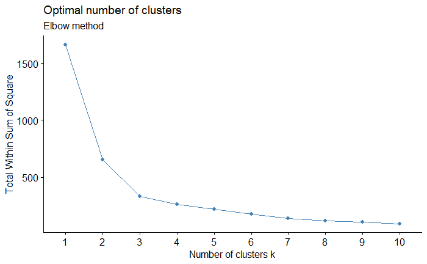

```r
fviz_nbclust(scaled_pca_data,kmeans,method = "wss",nstart = 25)+
  labs(subtitle = "Elbow method")
```

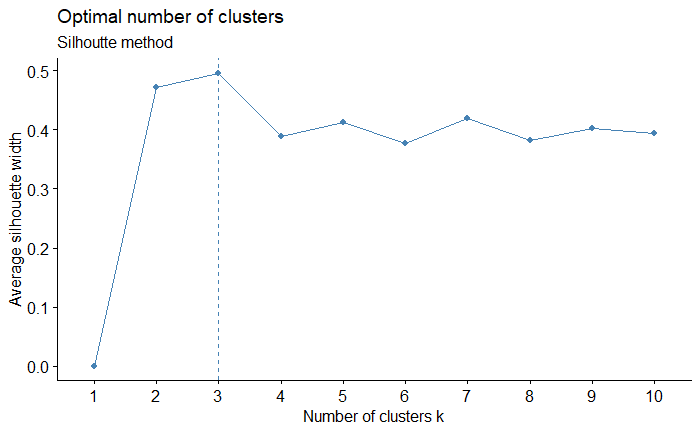

```r
fviz_nbclust(scaled_pca_data,kmeans,method = "silhouette")+ #for average silhouette width
  labs(subtitle = "Silhoutte method")
```

The silhouette method indicates the average silhouette width for different numbers of clusters. Although the maximum silhouette width is observed at k=3, the silhouette method generally shows a tendency to indicate k=2. Therefore, it is not considered as a primary determinant in this analysis. Additionally, the silhouette method also suggests that k=5 and k=7 could be meaningful, showing reasonably high silhouette widths.

##Gap Statistic Method

[output not shown]

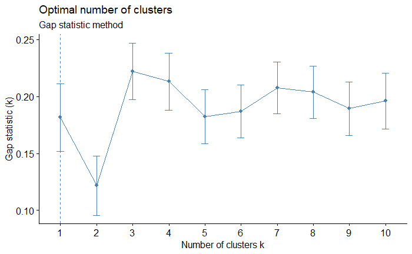

```r
fviz_nbclust(scaled_pca_data, kmeans, nstart = 25,  method = "gap_stat", nboot = 500)+
  labs(subtitle = "Gap statistic method")
```

The gap statistic method compares the log of within-cluster dispersion with that expected under a null reference distribution of the data. In this graph, k=3 also shows a significant gap, suggesting that 3 clusters might be optimal. However, there are also noticeable gaps at higher values such as k=7, indicating that more clusters might also be meaningful to explore.

## General Conclusion

Considering the elbow, silhouette, and gap statistic methods, it is suggested that 3 clusters are the most optimal for this dataset. However, the silhouette and gap statistic methods also suggest exploring 7 clusters could provide additional insights. Therefore, further analysis will be conducted with 3 and 7 clusters to determine the most meaningful cluster structure. The primary focus will be on 3 clusters, with 7 clusters being explored as an alternative.

#K-MEANS

## FOR 3 CLUSTERS

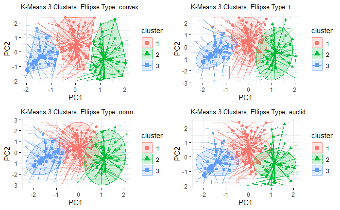

```r
km_res_3 <- kmeans(scaled_pca_data, 3, nstart=25)
ellipse_types <- c("convex", "t", "norm", "euclid")
k_3plots <- list()

for (etype in ellipse_types) {
  p <- fviz_cluster(km_res_3, data = scaled_pca_data,
                    ellipse.type = etype,
                    star.plot = TRUE,
                    repel = TRUE,
                    labelsize = 0,
                    ggtheme = theme_minimal()
  ) + labs(title = paste("K-Means 3 Clusters, Ellipse Type:", etype)) +
      theme(plot.title = element_text(size = 10))
  k_3plots[[etype]] <- p
}

grid.arrange(grobs = k_3plots, ncol = 2)
```

The visualization of K-Means clustering with 3 clusters using different ellipse types shows the general distribution and separation of the clusters. Each plot, whether using convex, t, norm, or Euclid ellipses, demonstrates that while clusters are forming, there is some degree of overlap between them.

The Euclid ellipse type, which aligns with the distance metric used in K-Means clustering, offers the most distinct representation of the clusters, even though overlaps are still present. This indicates that while the clustering captures significant patterns in the data, some similarities between clusters persist. Overall, the clusters are reasonably well-formed, and the visualizations provide a clear understanding of their distribution.

In conclusion, the clustering shows meaningful separation, and the Euclid ellipse type provides a particularly clear view of the cluster boundaries. Further analysis and refinement could improve the distinctness of the clusters, but the current results suggest that three clusters are a reasonable choice for this dataset.

## FOR 7 CLUSTERS

[figure not shown]

```r
km_res_7 <- kmeans(scaled_pca_data, 7, nstart=25)
ellipse_types <- c("convex", "t", "norm", "euclid")
k_7plots <- list()

for (etype in ellipse_types) {
  p <- fviz_cluster(km_res_7, data = scaled_pca_data,
                    ellipse.type = etype,
                    star.plot = TRUE,
                    repel = TRUE,
                    labelsize = 0,
                    ggtheme = theme_minimal()
  ) + labs(title = paste("K-Means 6 Clusters, Ellipse Type:", etype)) +
      theme(plot.title = element_text(size = 10))
  k_7plots[[etype]] <- p
}

grid.arrange(grobs = k_7plots, ncol = 2)
```

The visualization of K-Means clustering with 7 clusters using various ellipse types—convex, t, norm, and Euclid—illustrates a more complex distribution and less distinct separation compared to the 3-cluster scenario. The increased number of clusters results in greater overlap among them, making it challenging to clearly differentiate each cluster.

The Euclid ellipse type, while providing a more consistent representation aligned with the distance metric used in clustering, still shows significant overlap. This indicates that while the clustering algorithm identifies distinct groupings, the data’s inherent similarities lead to blurred boundaries between some clusters.

Overall, the clusters are not as distinctly separated, suggesting that 7 clusters may introduce more complexity than clarity. However, the results still provide valuable insights into the data’s structure, highlighting areas where clusters are more densely packed or significantly overlapping. Further refinement and analysis might be necessary to achieve clearer separation, but the current visualization suggests that fewer clusters might offer more distinct groupings.